```python
# Kiley Huffman
# QBIO 465
# Assignment 7
# Due: Thursday, 4/3
```

# Q1: Autoencoder Training for Dimensionality Reduction

● Load the counts and labels. ● Train a fully connected autoencoder to learn a low-dimensional representation of the gene expression data. ● Use two different latent space sizes: 10 and 50 (i.e., build two separate models). ● Use Mean Squared Error (MSE) as the loss function. ● Train the model for approximately 50 epochs (adjust as needed for optimal results). ● Report the training and testing history plots.

```python
import numpy as np
import matplotlib.pyplot as plt
from tensorflow import keras
from tensorflow.keras import layers

# Load the counts and labels
counts = np.load("counts.npy")  # Shape: (5000, 1000)
labels = np.loadtxt("labels.txt", dtype=int)  # Shape: (5000,)
```

```
2025-03-25 12:46:20.004862: I tensorflow/core/platform/cpu_feature_guard.cc:210] This TensorFlow binary is optimized to use available CPU instructions in performance-critical operations.
To enable the following instructions: AVX2 FMA, in other operations, rebuild TensorFlow with the appropriate compiler flags.
```

```python
# Train a fully connected autoencoder to learn a low-dimensional representation of the gene expression data.
# Use two different latent space sizes: 10 and 50 (i.e., build two separate models).

# Use a symmetric encoder-decoder architecture (e.g., 1000 -> 100 -> 10 for encoding and 10 -> 100 -> 1000 for decoding).
# Do not use activation functions in the input, latent, or output layers.
# Normalization of input data is not required.

def build_autoencoder(input_dim, latent_dim):
    # Encoder
    input_layer = keras.Input(shape=(input_dim,))
    encoded = layers.Dense(100, activation=None)(input_layer)
    latent = layers.Dense(latent_dim, activation=None)(encoded)

    # Decoder
    decoded = layers.Dense(100, activation=None)(latent)
    output_layer = layers.Dense(input_dim, activation=None)(decoded)

    # Model
    autoencoder = keras.Model(input_layer, output_layer)
    autoencoder.compile(optimizer="adam", loss="mse") # Use Mean Squared Error (MSE) as the loss function

    return autoencoder

input_dim = counts.shape[1]  # 1000 genes

# Train Autoencoder with Latent Size = 10, for 50 epochs
autoencoder_10 = build_autoencoder(input_dim, 10)
history_10 = autoencoder_10.fit(counts, counts, epochs=50, batch_size=32, validation_split=0.2, verbose=1)

# Train Autoencoder with Latent Size = 50, for 50 epochs
autoencoder_50 = build_autoencoder(input_dim, 50)
history_50 = autoencoder_50.fit(counts, counts, epochs=50, batch_size=32, validation_split=0.2, verbose=1)
```

```
125/125 ━━━━━━━━━━━━━━━━━━━━ 3s 9ms/step - loss: 6.6619 - val_loss: 2.6931
125/125 ━━━━━━━━━━━━━━━━━━━━ 1s 9ms/step - loss: 2.6753 - val_loss: 2.6485
125/125 ━━━━━━━━━━━━━━━━━━━━ 1s 9ms/step - loss: 2.6266 - val_loss: 2.6218
125/125 ━━━━━━━━━━━━━━━━━━━━ 1s 6ms/step - loss: 2.6068 - val_loss: 2.6070
125/125 ━━━━━━━━━━━━━━━━━━━━ 1s 5ms/step - loss: 2.5867 - val_loss: 2.5875
125/125 ━━━━━━━━━━━━━━━━━━━━ 1s 6ms/step - loss: 2.5761 - val_loss: 2.5834
125/125 ━━━━━━━━━━━━━━━━━━━━ 1s 5ms/step - loss: 2.5738 - val_loss: 2.5770
125/125 ━━━━━━━━━━━━━━━━━━━━ 1s 6ms/step - loss: 2.5701 - val_loss: 2.5719
125/125 ━━━━━━━━━━━━━━━━━━━━ 1s 5ms/step - loss: 2.5592 - val_loss: 2.5695
125/125 ━━━━━━━━━━━━━━━━━━━━ 1s 6ms/step - loss: 2.5454 - val_loss: 2.5708
125/125 ━━━━━━━━━━━━━━━━━━━━ 1s 7ms/step - loss: 2.5537 - val_loss: 2.5715
125/125 ━━━━━━━━━━━━━━━━━━━━ 1s 8ms/step - loss: 2.5525 - val_loss: 2.5668
125/125 ━━━━━━━━━━━━━━━━━━━━ 1s 7ms/step - loss: 2.5438 - val_loss: 2.5630
125/125 ━━━━━━━━━━━━━━━━━━━━ 1s 6ms/step - loss: 2.5509 - val_loss: 2.5624
125/125 ━━━━━━━━━━━━━━━━━━━━ 1s 6ms/step - loss: 2.5441 - val_loss: 2.5605
125/125 ━━━━━━━━━━━━━━━━━━━━ 1s 7ms/step - loss: 2.5425 - val_loss: 2.5620
125/125 ━━━━━━━━━━━━━━━━━━━━ 1s 6ms/step - loss: 2.5406 - val_loss: 2.5588
125/125 ━━━━━━━━━━━━━━━━━━━━ 1s 8ms/step - loss: 2.5390 - val_loss: 2.5595
125/125 ━━━━━━━━━━━━━━━━━━━━ 1s 6ms/step - loss: 2.5421 - val_loss: 2.5571
125/125 ━━━━━━━━━━━━━━━━━━━━ 1s 6ms/step - loss: 2.5438 - val_loss: 2.5570
125/125 ━━━━━━━━━━━━━━━━━━━━ 1s 7ms/step - loss: 2.5398 - val_loss: 2.5591
125/125 ━━━━━━━━━━━━━━━━━━━━ 2s 11ms/step - loss: 2.5449 - val_loss: 2.5581
125/125 ━━━━━━━━━━━━━━━━━━━━ 1s 7ms/step - loss: 2.5432 - val_loss: 2.5557
125/125 ━━━━━━━━━━━━━━━━━━━━ 1s 10ms/step - loss: 2.5320 - val_loss: 2.5548
125/125 ━━━━━━━━━━━━━━━━━━━━ 1s 9ms/step - loss: 2.5312 - val_loss: 2.5579
125/125 ━━━━━━━━━━━━━━━━━━━━ 1s 6ms/step - loss: 2.5298 - val_loss: 2.5550
125/125 ━━━━━━━━━━━━━━━━━━━━ 1s 10ms/step - loss: 2.5443 - val_loss: 2.5559
125/125 ━━━━━━━━━━━━━━━━━━━━ 1s 9ms/step - loss: 2.5387 - val_loss: 2.5578
125/125 ━━━━━━━━━━━━━━━━━━━━ 1s 11ms/step - loss: 2.5279 - val_loss: 2.5598
125/125 ━━━━━━━━━━━━━━━━━━━━ 2s 5ms/step - loss: 2.5342 - val_loss: 2.5538
125/125 ━━━━━━━━━━━━━━━━━━━━ 1s 5ms/step - loss: 2.5362 - val_loss: 2.5555
125/125 ━━━━━━━━━━━━━━━━━━━━ 1s 5ms/step - loss: 2.5308 - val_loss: 2.5542
125/125 ━━━━━━━━━━━━━━━━━━━━ 1s 6ms/step - loss: 2.5336 - val_loss: 2.5556
125/125 ━━━━━━━━━━━━━━━━━━━━ 1s 5ms/step - loss: 2.5353 - val_loss: 2.5539
125/125 ━━━━━━━━━━━━━━━━━━━━ 1s 8ms/step - loss: 2.5315 - val_loss: 2.5574
125/125 ━━━━━━━━━━━━━━━━━━━━ 1s 6ms/step - loss: 2.5284 - val_loss: 2.5546
125/125 ━━━━━━━━━━━━━━━━━━━━ 1s 5ms/step - loss: 2.5334 - val_loss: 2.5552
125/125 ━━━━━━━━━━━━━━━━━━━━ 1s 5ms/step - loss: 2.5316 - val_loss: 2.5554
125/125 ━━━━━━━━━━━━━━━━━━━━ 1s 5ms/step - loss: 2.5305 - val_loss: 2.5533
125/125 ━━━━━━━━━━━━━━━━━━━━ 2s 9ms/step - loss: 2.5334 - val_loss: 2.5530
```

[output cut: 45 more lines]

```
125/125 ━━━━━━━━━━━━━━━━━━━━ 2s 12ms/step - loss: 2.3360 - val_loss: 2.4240
125/125 ━━━━━━━━━━━━━━━━━━━━ 1s 7ms/step - loss: 2.3138 - val_loss: 2.4179
125/125 ━━━━━━━━━━━━━━━━━━━━ 1s 8ms/step - loss: 2.3021 - val_loss: 2.4158
125/125 ━━━━━━━━━━━━━━━━━━━━ 1s 6ms/step - loss: 2.2934 - val_loss: 2.4131
125/125 ━━━━━━━━━━━━━━━━━━━━ 1s 6ms/step - loss: 2.3023 - val_loss: 2.4119
125/125 ━━━━━━━━━━━━━━━━━━━━ 2s 17ms/step - loss: 2.2993 - val_loss: 2.4089
125/125 ━━━━━━━━━━━━━━━━━━━━ 2s 9ms/step - loss: 2.2938 - val_loss: 2.4082
125/125 ━━━━━━━━━━━━━━━━━━━━ 2s 13ms/step - loss: 2.2978 - val_loss: 2.4068
125/125 ━━━━━━━━━━━━━━━━━━━━ 1s 10ms/step - loss: 2.2925 - val_loss: 2.4060
125/125 ━━━━━━━━━━━━━━━━━━━━ 1s 9ms/step - loss: 2.2865 - val_loss: 2.4065
125/125 ━━━━━━━━━━━━━━━━━━━━ 2s 12ms/step - loss: 2.2868 - val_loss: 2.4047
125/125 ━━━━━━━━━━━━━━━━━━━━ 1s 8ms/step - loss: 2.2887 - val_loss: 2.4045
125/125 ━━━━━━━━━━━━━━━━━━━━ 1s 9ms/step - loss: 2.2788 - val_loss: 2.4034
125/125 ━━━━━━━━━━━━━━━━━━━━ 1s 6ms/step - loss: 2.2899 - val_loss: 2.4035
125/125 ━━━━━━━━━━━━━━━━━━━━ 1s 6ms/step - loss: 2.2807 - val_loss: 2.4023
```

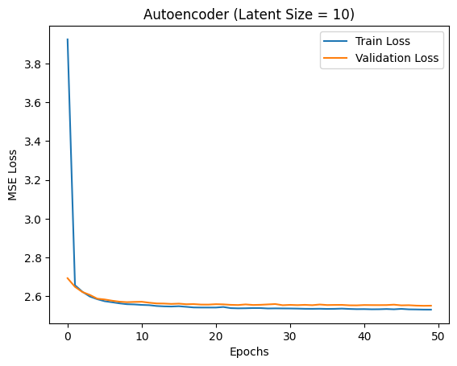

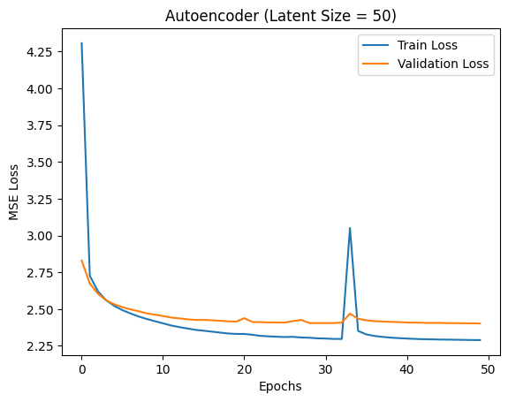

```python
# Report the training and testing history plots.
def plot_history(history, title):
    plt.plot(history.history["loss"], label="Train Loss")
    plt.plot(history.history["val_loss"], label="Validation Loss")
    plt.xlabel("Epochs")
    plt.ylabel("MSE Loss")
    plt.legend()
    plt.title(title)
    plt.show()

# Plot the loss curves
plot_history(history_10, "Autoencoder (Latent Size = 10)")
plot_history(history_50, "Autoencoder (Latent Size = 50)")
```

# Q2: Reconstruction Error Analysis

● Compare the training and testing history plots for the models with latent space sizes of 10 and 50:

● Report the MSE between the reconstructed data and the original data for each latent space size:

This is answered by the code below.

```python
from sklearn.metrics import mean_squared_error

# Get reconstructed outputs
reconstructed_10 = autoencoder_10.predict(counts)
reconstructed_50 = autoencoder_50.predict(counts)

# Compute MSE
mse_10 = mean_squared_error(counts.flatten(), reconstructed_10.flatten())
mse_50 = mean_squared_error(counts.flatten(), reconstructed_50.flatten())

# Print Results
print("")
print("THE MSE between the reconstructed data and the original data for each latent space size.")
print(f"MSE for Latent Size 10: {mse_10:.6f}")
print(f"MSE for Latent Size 50: {mse_50:.6f}")
```

```
157/157 ━━━━━━━━━━━━━━━━━━━━ 1s 5ms/step
157/157 ━━━━━━━━━━━━━━━━━━━━ 0s 3ms/step

THE MSE between the reconstructed data and the original data for each latent space size.
MSE for Latent Size 10: 2.530260
MSE for Latent Size 50: 2.299776
```

# Discuss:

● Discuss the differences in convergence speed between the two models:

When the Latent Size = 10, the model converges faster because the model has fewer trainable parameters. Thus, the encoder compresses the input into a smaller representation, leading to faster learning as there are fewer features to optimize. Due to significant information loss, however, it plateaus at a higher MSE, meaning it reaches convergence quickly but does not reconstruct the data well. When the Latent Size = 50, the model converges more slowly because it has more trainable parameters and retains more features. Thus, the model captures more complex structures in the gene expression data, but this requires more epochs to optimize. As a result, it achieves a lower final MSE because it better preserves the input information.

● Explain how the latent space size (10 vs. 50) affects the reconstruction error, and in particular, why one model might achieve a lower final MSE despite converging more slowly:

The latent space size affectts the reconstruction error by determining how much information the model can retain. When Latent Size = 10, this forces the model to compress the 1000-dimensional gene expression data into a much smaller space, leading to a higher reconstruction error because a lot of the original variation is lost. Hence, The model can still capture some major patterns but struggles with finer details. When the Latent Size = 50, it provides a better balance between compression and information retention, which helps achieve a lower reconstruction error despite taking longer to converge. Consequently, the model can capture more gene expression relationships, leading to a more accurate reconstruction.

# Q3: Visualization of Reconstructions

```
157/157 ━━━━━━━━━━━━━━━━━━━━ 1s 3ms/step
```

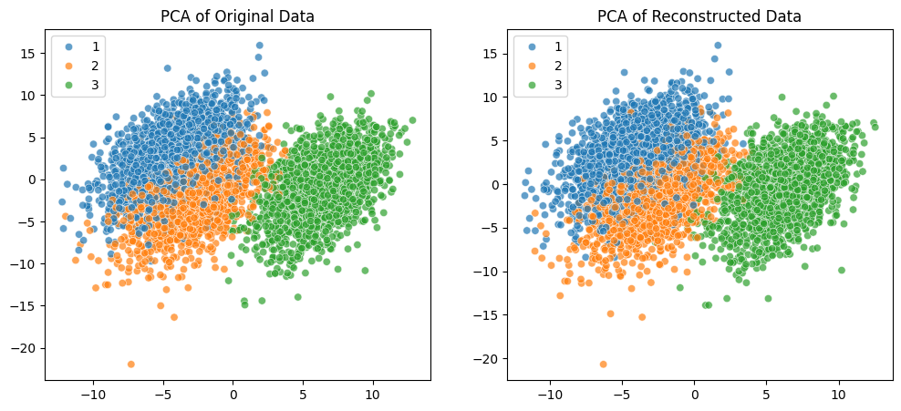

```python
import numpy as np
import pandas as pd
from sklearn.decomposition import PCA
from sklearn.manifold import TSNE
import seaborn as sns

# Get reconstructed data from autoencoder (latent space = 10)
reconstructed_10 = autoencoder_10.predict(counts)

# Generate PCA plots comparing the original data to the reconstructed data.
def plot_pca(original, reconstructed, labels):
    pca = PCA(n_components=2)
    original_pca = pca.fit_transform(original)
    reconstructed_pca = pca.transform(reconstructed)

    plt.figure(figsize=(12, 5))

    # Original PCA
    plt.subplot(1, 2, 1)
    sns.scatterplot(x=original_pca[:, 0], y=original_pca[:, 1], hue=labels, palette="tab10", alpha=0.7)
    plt.title("PCA of Original Data")

    # Reconstructed PCA
    plt.subplot(1, 2, 2)
    sns.scatterplot(x=reconstructed_pca[:, 0], y=reconstructed_pca[:, 1], hue=labels, palette="tab10", alpha=0.7)
    plt.title("PCA of Reconstructed Data")

    plt.show()

plot_pca(counts, reconstructed_10, labels) # Use labels.txt as labels when plotting
```

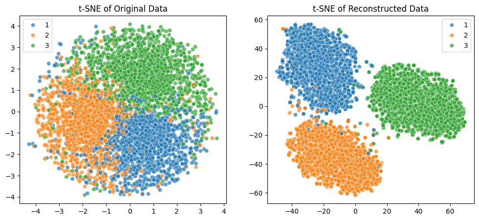

```python
# Generate t-SNE plots comparing the original data to the reconstructed data.
def plot_tsne(original, reconstructed, labels):
    tsne = TSNE(n_components=2, perplexity=30, random_state=42)
    original_tsne = tsne.fit_transform(original)
    reconstructed_tsne = tsne.fit_transform(reconstructed)

    plt.figure(figsize=(12, 5))

    # Original t-SNE
    plt.subplot(1, 2, 1)
    sns.scatterplot(x=original_tsne[:, 0], y=original_tsne[:, 1], hue=labels, palette="tab10", alpha=0.7)
    plt.title("t-SNE of Original Data")

    # Reconstructed t-SNE
    plt.subplot(1, 2, 2)
    sns.scatterplot(x=reconstructed_tsne[:, 0], y=reconstructed_tsne[:, 1], hue=labels, palette="tab10", alpha=0.7)
    plt.title("t-SNE of Reconstructed Data")

    plt.show()

plot_tsne(counts, reconstructed_10, labels) # Use labels.txt as labels when plotting
```

Compare the PCA and t-SNE visualizations between the original and reconstructed data:

# Discuss:

● Discuss any observable differences in clustering between the original and reconstructed data for PCA and t-SNE ● Explain possible reasons for these differences based on the autoencoder's reconstruction process.

PCA: In the original data, the clusters are well-separated, but in the reconstructed data, the clusters are slighly more compressed. This may be due to reconstruction errors. For instance, when the autoencoder has a small latent space, like one equal to 10, the model might lose global structure, causing cluster boundaries to become less distinct. If the latent spac was larger, the reconstruction would likely be more accurate and lead to better cluster separation.

# Q4: Latent Space Visualization with 2-Dimensional Latent Space

● Retrain the autoencoder with a latent space of 2 dimensions.

● Extract the 2-dimensional latent representations.

● Create a 2D scatter plot of the latent space, using labels.txt to color-code the clusters.

```python
import numpy as np
import matplotlib.pyplot as plt
import tensorflow as tf
from tensorflow import keras
from tensorflow.keras.layers import Input, Dense
from sklearn.preprocessing import LabelEncoder

# Load the data
counts = np.load("counts.npy")  # (5000, 1000)
labels = np.loadtxt("labels.txt", dtype=str)  # (5000,)

# Encode labels to integers for color mapping
label_encoder = LabelEncoder()
labels_encoded = label_encoder.fit_transform(labels)

# Define Autoencoder with Latent Size = 2
input_dim = counts.shape[1]  # 1000 genes

# Encoder
inputs = Input(shape=(input_dim,))
encoded = Dense(100, activation="relu")(inputs)
latent = Dense(2, activation=None)(encoded)  # Latent space (2D)

# Decoder
decoded = Dense(100, activation="relu")(latent)
outputs = Dense(input_dim, activation=None)(decoded)

# Build Model
autoencoder = keras.Model(inputs, outputs)
autoencoder.compile(optimizer="adam", loss="mse")

# Retrain the model
autoencoder.fit(counts, counts, epochs=50, batch_size=32, validation_split=0.2, verbose=1)

# Extract 2D Latent Representations
encoder = keras.Model(inputs, latent)
latent_representations = encoder.predict(counts)  # Shape: (5000, 2)
```

```
125/125 ━━━━━━━━━━━━━━━━━━━━ 6s 20ms/step - loss: 6.4732 - val_loss: 2.6421
125/125 ━━━━━━━━━━━━━━━━━━━━ 1s 9ms/step - loss: 2.6423 - val_loss: 2.6379
125/125 ━━━━━━━━━━━━━━━━━━━━ 1s 9ms/step - loss: 2.6280 - val_loss: 2.6357
125/125 ━━━━━━━━━━━━━━━━━━━━ 2s 12ms/step - loss: 2.6310 - val_loss: 2.6263
125/125 ━━━━━━━━━━━━━━━━━━━━ 2s 13ms/step - loss: 2.6240 - val_loss: 2.6151
125/125 ━━━━━━━━━━━━━━━━━━━━ 2s 12ms/step - loss: 2.6211 - val_loss: 2.6130
125/125 ━━━━━━━━━━━━━━━━━━━━ 3s 13ms/step - loss: 2.6083 - val_loss: 2.6102
125/125 ━━━━━━━━━━━━━━━━━━━━ 2s 8ms/step - loss: 2.6092 - val_loss: 2.6083
125/125 ━━━━━━━━━━━━━━━━━━━━ 1s 8ms/step - loss: 2.6073 - val_loss: 2.6087
125/125 ━━━━━━━━━━━━━━━━━━━━ 1s 10ms/step - loss: 2.6106 - val_loss: 2.6095
125/125 ━━━━━━━━━━━━━━━━━━━━ 1s 12ms/step - loss: 2.6054 - val_loss: 2.6065
125/125 ━━━━━━━━━━━━━━━━━━━━ 2s 12ms/step - loss: 2.6008 - val_loss: 2.6058
125/125 ━━━━━━━━━━━━━━━━━━━━ 1s 11ms/step - loss: 2.6051 - val_loss: 2.6047
125/125 ━━━━━━━━━━━━━━━━━━━━ 2s 13ms/step - loss: 2.6119 - val_loss: 2.6065
125/125 ━━━━━━━━━━━━━━━━━━━━ 1s 11ms/step - loss: 2.6013 - val_loss: 2.6016
125/125 ━━━━━━━━━━━━━━━━━━━━ 3s 11ms/step - loss: 2.5929 - val_loss: 2.6023
125/125 ━━━━━━━━━━━━━━━━━━━━ 1s 11ms/step - loss: 2.6044 - val_loss: 2.6066
125/125 ━━━━━━━━━━━━━━━━━━━━ 1s 8ms/step - loss: 2.5996 - val_loss: 2.6006
125/125 ━━━━━━━━━━━━━━━━━━━━ 1s 6ms/step - loss: 2.5992 - val_loss: 2.5994
125/125 ━━━━━━━━━━━━━━━━━━━━ 1s 7ms/step - loss: 2.5991 - val_loss: 2.5981
125/125 ━━━━━━━━━━━━━━━━━━━━ 1s 7ms/step - loss: 2.5986 - val_loss: 2.5984
125/125 ━━━━━━━━━━━━━━━━━━━━ 1s 10ms/step - loss: 2.5927 - val_loss: 2.5977
125/125 ━━━━━━━━━━━━━━━━━━━━ 1s 10ms/step - loss: 2.5925 - val_loss: 2.5985
125/125 ━━━━━━━━━━━━━━━━━━━━ 1s 8ms/step - loss: 2.5956 - val_loss: 2.5967
125/125 ━━━━━━━━━━━━━━━━━━━━ 2s 12ms/step - loss: 2.5870 - val_loss: 2.5999
125/125 ━━━━━━━━━━━━━━━━━━━━ 2s 12ms/step - loss: 2.5910 - val_loss: 2.5961
125/125 ━━━━━━━━━━━━━━━━━━━━ 2s 12ms/step - loss: 2.5960 - val_loss: 2.5959
125/125 ━━━━━━━━━━━━━━━━━━━━ 1s 11ms/step - loss: 2.5936 - val_loss: 2.5953
125/125 ━━━━━━━━━━━━━━━━━━━━ 2s 12ms/step - loss: 2.5839 - val_loss: 2.5944
125/125 ━━━━━━━━━━━━━━━━━━━━ 1s 8ms/step - loss: 2.6007 - val_loss: 2.5927
125/125 ━━━━━━━━━━━━━━━━━━━━ 1s 9ms/step - loss: 2.5896 - val_loss: 2.5980
125/125 ━━━━━━━━━━━━━━━━━━━━ 1s 10ms/step - loss: 2.5947 - val_loss: 2.5943
125/125 ━━━━━━━━━━━━━━━━━━━━ 1s 9ms/step - loss: 2.5878 - val_loss: 2.5927
125/125 ━━━━━━━━━━━━━━━━━━━━ 1s 10ms/step - loss: 2.5908 - val_loss: 2.5939
125/125 ━━━━━━━━━━━━━━━━━━━━ 2s 6ms/step - loss: 2.5901 - val_loss: 2.5932
125/125 ━━━━━━━━━━━━━━━━━━━━ 1s 10ms/step - loss: 2.5945 - val_loss: 2.5937
125/125 ━━━━━━━━━━━━━━━━━━━━ 2s 8ms/step - loss: 2.5806 - val_loss: 2.5942
125/125 ━━━━━━━━━━━━━━━━━━━━ 1s 6ms/step - loss: 2.5863 - val_loss: 2.5926
125/125 ━━━━━━━━━━━━━━━━━━━━ 1s 5ms/step - loss: 2.5895 - val_loss: 2.5954
125/125 ━━━━━━━━━━━━━━━━━━━━ 1s 6ms/step - loss: 2.5923 - val_loss: 2.5917
125/125 ━━━━━━━━━━━━━━━━━━━━ 1s 7ms/step - loss: 2.5857 - val_loss: 2.5918
125/125 ━━━━━━━━━━━━━━━━━━━━ 1s 6ms/step - loss: 2.5881 - val_loss: 2.5940
125/125 ━━━━━━━━━━━━━━━━━━━━ 1s 6ms/step - loss: 2.5844 - val_loss: 2.5924
125/125 ━━━━━━━━━━━━━━━━━━━━ 1s 5ms/step - loss: 2.5835 - val_loss: 2.5926
125/125 ━━━━━━━━━━━━━━━━━━━━ 1s 6ms/step - loss: 2.5882 - val_loss: 2.5903
125/125 ━━━━━━━━━━━━━━━━━━━━ 1s 7ms/step - loss: 2.5845 - val_loss: 2.5910
125/125 ━━━━━━━━━━━━━━━━━━━━ 1s 5ms/step - loss: 2.5885 - val_loss: 2.5915
125/125 ━━━━━━━━━━━━━━━━━━━━ 1s 5ms/step - loss: 2.5867 - val_loss: 2.5916
125/125 ━━━━━━━━━━━━━━━━━━━━ 1s 5ms/step - loss: 2.5835 - val_loss: 2.5905
125/125 ━━━━━━━━━━━━━━━━━━━━ 1s 5ms/step - loss: 2.5837 - val_loss: 2.5897
157/157 ━━━━━━━━━━━━━━━━━━━━ 0s 2ms/step
```

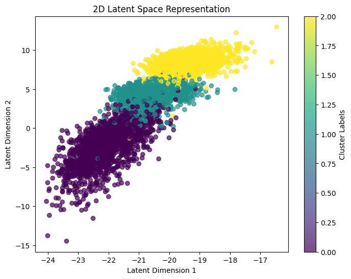

```python
# Plot 2D Latent Space
# Create a 2D scatter plot of the latent space, using labels.txt to color-code the clusters.
plt.figure(figsize=(8, 6))
scatter = plt.scatter(latent_representations[:, 0], latent_representations[:, 1],
                      c=labels_encoded, cmap="viridis", alpha=0.7)
plt.colorbar(scatter, label="Cluster Labels")
plt.xlabel("Latent Dimension 1")
plt.ylabel("Latent Dimension 2")
plt.title("2D Latent Space Representation")
plt.show()
```

# Discuss:

● Discuss the observed clustering in the 2D latent space, including how well the clusters are separated and what the results suggest about the autoencoder’s ability to capture the underlying structure of the data:

In the 2D latent space, the clusters are well-separated, indicating the autoencoder has successfully captured meaningful structure in the gene expression data. However, there is some overlap, likely due to compression from 1000 dimensions → 2 dimensions, causing some loss of fine-grained information. Since the clusters remain distinct, this suggest the autoencoder has learned key gene expression features that differentiate the cell types. Overall, the 2D latent space captures some clustering, but higher-dimensional representations would likely provide better reconstruction and separation.

# Q5: Alternative Loss Function Experiment

Replace the MSE loss with the following custom loss function when training the autoencoder (using a latent space size of 10):

```python
import numpy as np
import tensorflow as tf
from tensorflow.keras import layers, models
import matplotlib.pyplot as plt
from sklearn.decomposition import PCA
from sklearn.manifold import TSNE
import seaborn as sns

# Define autoencoder model
def build_autoencoder(latent_dim):
    input_dim = counts.shape[1]
    encoder = models.Sequential([
        layers.InputLayer(input_shape=(input_dim,)),
        layers.Dense(100, activation=None),
        layers.Dense(latent_dim, activation=None)
    ])
    decoder = models.Sequential([
        layers.InputLayer(input_shape=(latent_dim,)),
        layers.Dense(100, activation=None),
        layers.Dense(input_dim, activation=None)
    ])
    autoencoder = models.Sequential([encoder, decoder])
    return autoencoder, encoder

# Custom loss function
def nonzero_mse_loss(y_true, y_pred):
    # Create a mask for nonzero elements
    mask = tf.cast(tf.math.not_equal(y_true, 0), tf.float32)
    nonzero_count = tf.reduce_sum(mask)  # Count nonzero elements
    # Compute squared difference for nonzero elements
    nonzero_squared_diff = tf.square(y_true - y_pred * mask)
    # Compute mean squared error over nonzero elements
    nonzero_mse = tf.reduce_sum(nonzero_squared_diff) / nonzero_count
    return nonzero_mse

# Train autoencoders for latent sizes 10 and 50
latent_dims = [10, 50]
histories = {}
mse_scores = {}
for latent_dim in latent_dims:
    autoencoder, _ = build_autoencoder(latent_dim)
    autoencoder.compile(optimizer='adam', loss='mse')
    hist = autoencoder.fit(counts, counts, epochs=50, batch_size=32, validation_split=0.2, verbose=1)
    histories[latent_dim] = hist.history
    mse_scores[latent_dim] = autoencoder.evaluate(counts, counts)

# Train autoencoder with nonzero MSE loss
autoencoder_nz, _ = build_autoencoder(10)
autoencoder_nz.compile(optimizer='adam', loss=nonzero_mse_loss)
hist_nz = autoencoder_nz.fit(counts, counts, epochs=50, batch_size=32, validation_split=0.2, verbose=1)
mse_nz = autoencoder_nz.evaluate(counts, counts)
```

```
125/125 ━━━━━━━━━━━━━━━━━━━━ 2s 7ms/step - loss: 6.9575 - val_loss: 2.7044
125/125 ━━━━━━━━━━━━━━━━━━━━ 1s 6ms/step - loss: 2.6868 - val_loss: 2.6572
125/125 ━━━━━━━━━━━━━━━━━━━━ 1s 6ms/step - loss: 2.6361 - val_loss: 2.6258
125/125 ━━━━━━━━━━━━━━━━━━━━ 1s 7ms/step - loss: 2.6143 - val_loss: 2.6032
125/125 ━━━━━━━━━━━━━━━━━━━━ 1s 5ms/step - loss: 2.5861 - val_loss: 2.6182
125/125 ━━━━━━━━━━━━━━━━━━━━ 1s 5ms/step - loss: 2.5774 - val_loss: 2.5869
125/125 ━━━━━━━━━━━━━━━━━━━━ 1s 5ms/step - loss: 2.5705 - val_loss: 2.5788
125/125 ━━━━━━━━━━━━━━━━━━━━ 1s 5ms/step - loss: 2.5641 - val_loss: 2.5734
125/125 ━━━━━━━━━━━━━━━━━━━━ 1s 5ms/step - loss: 2.5603 - val_loss: 2.5742
125/125 ━━━━━━━━━━━━━━━━━━━━ 1s 5ms/step - loss: 2.5573 - val_loss: 2.5718
125/125 ━━━━━━━━━━━━━━━━━━━━ 1s 5ms/step - loss: 2.5518 - val_loss: 2.5707
125/125 ━━━━━━━━━━━━━━━━━━━━ 1s 4ms/step - loss: 2.5539 - val_loss: 2.5649
125/125 ━━━━━━━━━━━━━━━━━━━━ 1s 5ms/step - loss: 2.5663 - val_loss: 2.5645
125/125 ━━━━━━━━━━━━━━━━━━━━ 1s 5ms/step - loss: 2.5545 - val_loss: 2.5657
125/125 ━━━━━━━━━━━━━━━━━━━━ 1s 5ms/step - loss: 2.5483 - val_loss: 2.5645
125/125 ━━━━━━━━━━━━━━━━━━━━ 1s 6ms/step - loss: 2.5447 - val_loss: 2.5645
125/125 ━━━━━━━━━━━━━━━━━━━━ 1s 6ms/step - loss: 2.5426 - val_loss: 2.5624
125/125 ━━━━━━━━━━━━━━━━━━━━ 1s 6ms/step - loss: 2.5409 - val_loss: 2.5627
125/125 ━━━━━━━━━━━━━━━━━━━━ 1s 6ms/step - loss: 2.5438 - val_loss: 2.5570
125/125 ━━━━━━━━━━━━━━━━━━━━ 1s 8ms/step - loss: 2.5455 - val_loss: 2.5600
125/125 ━━━━━━━━━━━━━━━━━━━━ 1s 7ms/step - loss: 2.5432 - val_loss: 2.5609
125/125 ━━━━━━━━━━━━━━━━━━━━ 1s 6ms/step - loss: 2.5463 - val_loss: 2.5566
125/125 ━━━━━━━━━━━━━━━━━━━━ 1s 8ms/step - loss: 2.5427 - val_loss: 2.5553
125/125 ━━━━━━━━━━━━━━━━━━━━ 1s 11ms/step - loss: 2.5416 - val_loss: 2.5556
125/125 ━━━━━━━━━━━━━━━━━━━━ 1s 11ms/step - loss: 2.5455 - val_loss: 2.5561
125/125 ━━━━━━━━━━━━━━━━━━━━ 1s 11ms/step - loss: 2.5422 - val_loss: 2.5579
125/125 ━━━━━━━━━━━━━━━━━━━━ 1s 9ms/step - loss: 2.5468 - val_loss: 2.5558
125/125 ━━━━━━━━━━━━━━━━━━━━ 1s 8ms/step - loss: 2.5402 - val_loss: 2.5565
125/125 ━━━━━━━━━━━━━━━━━━━━ 1s 6ms/step - loss: 2.5343 - val_loss: 2.5556
125/125 ━━━━━━━━━━━━━━━━━━━━ 1s 8ms/step - loss: 2.5343 - val_loss: 2.5550
125/125 ━━━━━━━━━━━━━━━━━━━━ 1s 10ms/step - loss: 2.5395 - val_loss: 2.5536
125/125 ━━━━━━━━━━━━━━━━━━━━ 1s 7ms/step - loss: 2.5350 - val_loss: 2.5554
125/125 ━━━━━━━━━━━━━━━━━━━━ 1s 9ms/step - loss: 2.5335 - val_loss: 2.5547
125/125 ━━━━━━━━━━━━━━━━━━━━ 2s 12ms/step - loss: 2.5348 - val_loss: 2.5535
125/125 ━━━━━━━━━━━━━━━━━━━━ 2s 10ms/step - loss: 2.5383 - val_loss: 2.5560
125/125 ━━━━━━━━━━━━━━━━━━━━ 2s 8ms/step - loss: 2.5356 - val_loss: 2.5565
125/125 ━━━━━━━━━━━━━━━━━━━━ 1s 7ms/step - loss: 2.5311 - val_loss: 2.5546
125/125 ━━━━━━━━━━━━━━━━━━━━ 1s 6ms/step - loss: 2.5296 - val_loss: 2.5542
125/125 ━━━━━━━━━━━━━━━━━━━━ 1s 6ms/step - loss: 2.5389 - val_loss: 2.5545
125/125 ━━━━━━━━━━━━━━━━━━━━ 1s 5ms/step - loss: 2.5391 - val_loss: 2.5539
```

[output cut: 98 more lines]

```
125/125 ━━━━━━━━━━━━━━━━━━━━ 1s 6ms/step - loss: 0.2922 - val_loss: 0.3017
125/125 ━━━━━━━━━━━━━━━━━━━━ 1s 6ms/step - loss: 0.2928 - val_loss: 0.2996
125/125 ━━━━━━━━━━━━━━━━━━━━ 1s 5ms/step - loss: 0.2931 - val_loss: 0.2999
125/125 ━━━━━━━━━━━━━━━━━━━━ 1s 5ms/step - loss: 0.2916 - val_loss: 0.3049
125/125 ━━━━━━━━━━━━━━━━━━━━ 1s 5ms/step - loss: 0.2922 - val_loss: 0.2999
125/125 ━━━━━━━━━━━━━━━━━━━━ 1s 5ms/step - loss: 0.2892 - val_loss: 0.2997
125/125 ━━━━━━━━━━━━━━━━━━━━ 1s 6ms/step - loss: 0.2939 - val_loss: 0.2997
125/125 ━━━━━━━━━━━━━━━━━━━━ 1s 6ms/step - loss: 0.2899 - val_loss: 0.2978
125/125 ━━━━━━━━━━━━━━━━━━━━ 1s 7ms/step - loss: 0.2924 - val_loss: 0.3054
125/125 ━━━━━━━━━━━━━━━━━━━━ 1s 8ms/step - loss: 0.2900 - val_loss: 0.3050
125/125 ━━━━━━━━━━━━━━━━━━━━ 1s 7ms/step - loss: 0.2924 - val_loss: 0.2990
125/125 ━━━━━━━━━━━━━━━━━━━━ 1s 8ms/step - loss: 0.2913 - val_loss: 0.2996
125/125 ━━━━━━━━━━━━━━━━━━━━ 1s 9ms/step - loss: 0.2915 - val_loss: 0.2984
125/125 ━━━━━━━━━━━━━━━━━━━━ 1s 6ms/step - loss: 0.2902 - val_loss: 0.3015
157/157 ━━━━━━━━━━━━━━━━━━━━ 1s 3ms/step - loss: 0.2909
```

● After training with this alternative loss, do the following:

● Compare the reconstruction MSE from this experiment with the MSE reported in Q2:

```python
# Compare MSEs
print("MSE (Experiment 2 MSE, Latent Size = 10):", mse_10)
print("MSE (Nonzero MSE, Latent Size = 10):", mse_nz)
print("The reconstruction MSE for this experiment is much less than the MSE from Experiment 2.")
```

```
MSE (Experiment 2 MSE, Latent Size = 10): 2.530259847640991
MSE (Nonzero MSE, Latent Size = 10): 0.2925816774368286
The reconstruction MSE for this experiment is much less than the MSE from Experiment 2.
```

Generate the following four plots:

○ PCA plot: Reconstructed data vs. Original data.

○ PCA plot: Latent embeddings vs. Original data.

○ t-SNE plot: Reconstructed data vs. Original data.

○ t-SNE plot: Latent embeddings vs. Original data.

```
157/157 ━━━━━━━━━━━━━━━━━━━━ 0s 2ms/step
157/157 ━━━━━━━━━━━━━━━━━━━━ 0s 2ms/step
```

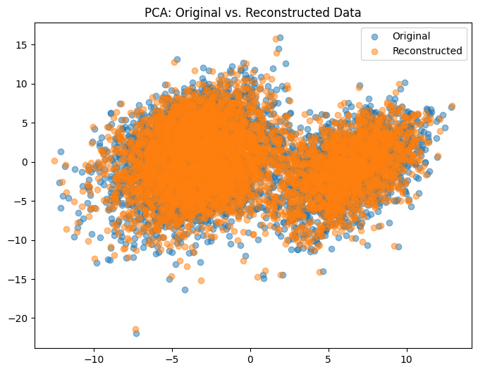

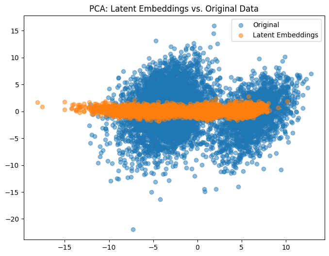

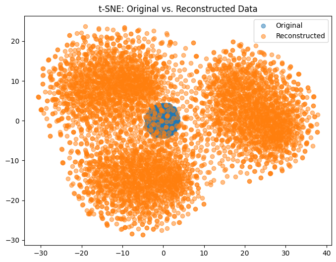

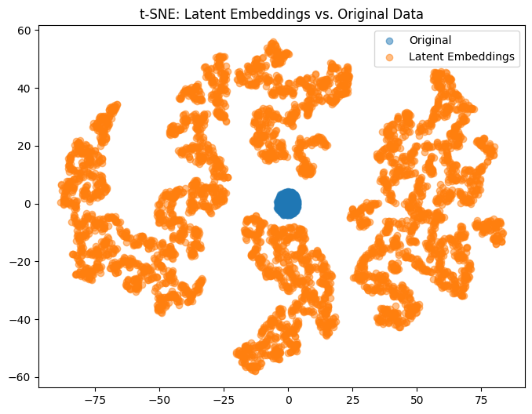

```python
# Get reconstructed data
X_reconstructed = autoencoder.predict(counts)
latent_embeddings = encoder.predict(counts)

# Compute PCA for Original vs. Reconstructed Data
pca = PCA(n_components=2)
X_original_pca = pca.fit_transform(counts)
X_reconstructed_pca = pca.transform(X_reconstructed)

plt.figure(figsize=(8,6))
plt.scatter(X_original_pca[:,0], X_original_pca[:,1], alpha=0.5, label="Original")
plt.scatter(X_reconstructed_pca[:,0], X_reconstructed_pca[:,1], alpha=0.5, label="Reconstructed")
plt.legend()
plt.title("PCA: Original vs. Reconstructed Data")
plt.show()

# PCA: Latent Embeddings vs. Original Data
X_latent_pca = pca.fit_transform(latent_embeddings)

plt.figure(figsize=(8,6))
plt.scatter(X_original_pca[:,0], X_original_pca[:,1], alpha=0.5, label="Original")
plt.scatter(X_latent_pca[:,0], X_latent_pca[:,1], alpha=0.5, label="Latent Embeddings")
plt.legend()
plt.title("PCA: Latent Embeddings vs. Original Data")
plt.show()

# Compute t-SNE for Original vs. Reconstructed Data
tsne = TSNE(n_components=2, random_state=42)
X_original_tsne = tsne.fit_transform(counts)
X_reconstructed_tsne = tsne.fit_transform(X_reconstructed)

plt.figure(figsize=(8,6))
plt.scatter(X_original_tsne[:,0], X_original_tsne[:,1], alpha=0.5, label="Original")
plt.scatter(X_reconstructed_tsne[:,0], X_reconstructed_tsne[:,1], alpha=0.5, label="Reconstructed")
plt.legend()
plt.title("t-SNE: Original vs. Reconstructed Data")
plt.show()

# t-SNE: Latent Embeddings vs. Original Data
X_latent_tsne = tsne.fit_transform(latent_embeddings)

plt.figure(figsize=(8,6))
plt.scatter(X_original_tsne[:,0], X_original_tsne[:,1], alpha=0.5, label="Original")
plt.scatter(X_latent_tsne[:,0], X_latent_tsne[:,1], alpha=0.5, label="Latent Embeddings")
plt.legend()
plt.title("t-SNE: Latent Embeddings vs. Original Data")
plt.show()
```

# Discuss:

● Discuss any observed differences, noting if the model with the new loss better captures the relevant structure in the data by focusing on nonzero values

PCA, Reconstructed Data vs. Original Data: The reconstructed cluster overlaps the original data structure, but the reconstructed cluster is more compact than the original data structure. Since the reconstructed data points overlap well with the original ones, the model has successfully retained important features.

PCA, Latent Embeddings vs. Original Data: The latent embeddings are clustered around a line, whereas the original data has the shape of a normal cluster.

t-SNE, Latent Embeddings vs. Original Data: The original data is clustered in a small, compact circle, whereas the rconstructed data appears in 5 separate clusters surrounding the original data. Since the clusters remain distinct, the model effectively captures meaningful structure. Sinc the plot still captures major clusters, the latent space is well-structured.